# MYC mice prostate

Mindy Kim Graham

6/14/2021

# Single cell analysis of mouse prostate (WT and Hi-MYC) at 6 months and 10 months

```r
# Libraries
library(Seurat)
```

```r
library(ggplot2)
library(sctransform)
library(dplyr)
library(DataCombine)
library(viridis)
library(tidyverse)
library(glmGamPoi)

# set working directory
wrkdir <- "C:/Users/mgraha21/OneDrive - Johns Hopkins/Mindy JHMI Onedrive/MYC prostate scRNAseq/Manuscript Version of Analysis/Github uploads" #update specific to user
setwd(wrkdir)
```

# Load gene x cell count matrices, merge and generate a seurat object

FASTQ and gene x cell count matrices available on NCBI GEO (GSE228945)

```
# Function to combine count matrices with matrices containing MYC annotations
merge_matrix <- function(matrix1, matrix2) {
  # create a vector with 0s and add it as a new row to matrix1. This new row will hold the data for the human MYC gene
  MYC <- rep(0, times = ncol(matrix1))
  matrix1 <- rbind(matrix1, MYC)
  # get the cells present in both matrices
  cells_myc <- intersect(colnames(matrix1), colnames(matrix2))
  # replace the 0 in the MYC row with their actual values from matrix2. Only the data for cells present in matrix1 and matrix2 will be replaced.
  matrix1[c("MYC"), cells_myc] <- matrix2[c("human_c-MYC"), cells_myc]
  # return the merged matrix
  return(matrix1)
}

# Load 6 month DLP WT and HiMYC libraries
DF1 <- Read10X(data.dir = "DF1/", strip.suffix = TRUE)
DF1_MYC <- Read10X(data.dir = "DF1_myc_featurecounts/")
DF1_merge <- merge_matrix(DF1, DF1_MYC)

DF2 <- Read10X(data.dir = "/DF2/", strip.suffix = TRUE)
DF2_MYC <- Read10X(data.dir = "DF2_myc_featurecounts/")
DF2_merge <- merge_matrix(DF2, DF2_MYC)

DHMF1 <- Read10X(data.dir = "DHMF1_filtered_feature_bc_matrix/", strip.suffix = TRUE)
DHMF1_MYC <- Read10X(data.dir = "DHMF1_myc_featurecounts/")
DHMF1_merge <- merge_matrix(DHMF1, DHMF1_MYC)

DHMF2 <- Read10X(data.dir = "DHMF2_filtered_feature_bc_matrix/", strip.suffix = TRUE)
DHMF2_MYC <- Read10X(data.dir = "DHMF2_myc_featurecounts/")
DHMF2_merge <- merge_matrix(DHMF2, DHMF2_MYC)

LF1 <- Read10X(data.dir = "LF1/", strip.suffix = TRUE)
LF1_MYC <- Read10X(data.dir = "LF1_myc_featurecounts/")
LF1_merge <- merge_matrix(LF1, LF1_MYC)

LF2 <- Read10X(data.dir = "LF2/", strip.suffix = TRUE)
LF2_MYC <- Read10X(data.dir = "LF2_myc_featurecounts/")
LF2_merge <- merge_matrix(LF2, LF2_MYC)

LHMF1 <- Read10X(data.dir = "LHMF1_filtered_feature_bc_matrix/", strip.suffix = TRUE)
LHMF1_MYC <- Read10X(data.dir = "LHMF1_myc_featurecounts/")
LHMF1_merge <- merge_matrix(LHMF1, LHMF1_MYC)

LHMF2 <- Read10X(data.dir = "LHMF2_filtered_feature_bc_matrix/", strip.suffix = TRUE)
LHMF2_MYC <- Read10X(data.dir = "LHMF2_myc_featurecounts/")
LHMF2_merge <- merge_matrix(LHMF2, LHMF2_MYC)

#  Load 10 month DLP WT and HiMYC libraries
# Function to combine count matrices with matrices containing MYC annotations
merge_matrix <- function(matrix1, matrix2) {
  # create a vector with 0s and add it as a new row to matrix1. This new row will hold the data for the human MYC gene
  MYC <- rep(0, times = ncol(matrix1))
  matrix1 <- rbind(matrix1, MYC)
  # get the cells present in both matrices
  cells_myc <- intersect(colnames(matrix1), colnames(matrix2))
  # replace the 0 in the MYC row with their actual values from matrix2. Only the data for cells present in matrix1 and matrix2 will be replaced.
  matrix1[c("MYC"), cells_myc] <- matrix2[c("human_MYC"), cells_myc]
  # return the merged matrix
  return(matrix1)
}

H13 <- Read10X(data.dir = "H13DGE_filtered_feature_bc_matrix/",
               strip.suffix = TRUE)
H13_MYC <- Read10X(data.dir = "H13DGE_MYC/")
H13_merge <- merge_matrix(H13, H13_MYC)

H23 <- Read10X(data.dir = "H23DGE_filtered_feature_bc_matrix/",
               strip.suffix = TRUE)
H23_MYC <- Read10X(data.dir = "H23DGE_MYC/")
H23_merge <- merge_matrix(H23, H23_MYC)

W13 <- Read10X(data.dir = "W13DGE_filtered_feature_bc_matrix/",
               strip.suffix = TRUE)
W13_MYC <- Read10X(data.dir = "W13DGE_MYC/")
W13_merge <- merge_matrix(W13, W13_MYC)

W23 <- Read10X(data.dir = "W23DGE_filtered_feature_bc_matrix/",
               strip.suffix = TRUE)
W23_MYC <- Read10X(data.dir = "W23DGE_MYC/")
W23_merge <- merge_matrix(W23, W23_MYC)

# Merge seurat objects
```

# create seurat object and integrate

https://satijalab.org/seurat/archive/v3.0/integration.html

```
# create a list with all the matrices
matrix.list <- c(WT_D6_1 = DF1_merge,
                 WT_D6_2 = DF2_merge,
                 WT_L6_1 = LF1_merge,
                 WT_L6_2 = LF2_merge,
                 HiMYC_D6_1 = DHMF1_merge,
                 HiMYC_D6_2 = DHMF2_merge,
                 HiMYC_L6_1 = LHMF1_merge,
                 HiMYC_L6_2 = LHMF2_merge,
                  WT_B9_1 = W13_merge,
                  WT_B9_2 = W23_merge,
                  HiMYC_B9_1 = H13_merge,
                  HiMYC_B9_2 = H23_merge)

# create empty list for Seurat objects
seurat.list <- vector(mode = "list")

# This for loop iterates through each matrix in the list, creates a Seurat object and then adds it to a new list. This new list will contain the Seurat objects
for (i in 1:length(matrix.list)) {
  seurat.object <- CreateSeuratObject(counts = matrix.list[[i]], project = names(matrix.list)[i], min.cells = 3, min.features = 200)
  seurat.list <- append(seurat.list, seurat.object)
}

# remove matrices
rm(DF1, DF1_MYC, DF1_merge,
   DF2, DF2_MYC, DF2_merge,
   LF1, LF1_MYC, LF1_merge,
   LF2, LF2_MYC, LF2_merge,
   DHMF1, DHMF1_MYC, DHMF1_merge,
   DHMF2, DHMF2_MYC, DHMF2_merge,
   LHMF1, LHMF1_MYC, LHMF1_merge,
   LHMF2, LHMF2_MYC, LHMF2_merge,
   W13, W13_MYC, W13_merge,
   W23, W23_MYC, W23_merge,
   H13, H13_MYC, H13_merge,
   H23, H23_MYC, H23_merge)
# perform sctransform on each seurat object
seurat.list <- lapply(X = seurat.list, FUN = SCTransform, method = "glmGamPoi", vst.flavor = "v2")

# integration
features <- SelectIntegrationFeatures(object.list = seurat.list, nfeatures = 3000)
seurat.list <- PrepSCTIntegration(object.list = seurat.list, anchor.features = features)
seurat.list <- lapply(X = seurat.list, FUN = RunPCA, features = features)

# integrate to reference HiMYC and WT 10 month old mice DLP
levels(seurat.list[[9]])
levels(seurat.list[[11]])
anchors <- FindIntegrationAnchors(object.list = seurat.list, normalization.method = "SCT",
    anchor.features = features, dims = 1:30, reduction = "rpca", k.anchor = 30, reference = c(9, 11))
seurat.int <- IntegrateData(anchorset = anchors, normalization.method = "SCT", dims = 1:30)

# remove anchors, unused lists
rm(anchors, matrix.list, seurat.list)
gc()

# save integrated object
saveRDS(seurat.int, file = "FVB_DLP_int.rds")
```

add metadata

```
# Add columns for genotype
seurat.int$genotype <- "WT"
seurat.int$genotype[substring(seurat.int@meta.data$orig.ident, 1, 1) == "H"] <- "MYC"
table(seurat.int$orig.ident, seurat.int$genotype)

# Add columns for age
seurat.int$age <- "6mo"
seurat.int$age[substring(seurat.int@meta.data$orig.ident, 5, 5) == "9"] <- "10mo"
seurat.int$age[substring(seurat.int@meta.data$orig.ident, 8, 8) == "9"] <- "10mo"
table(seurat.int$orig.ident, seurat.int$age)

# Add columns for lobe
seurat.int$lobe <- "Dorsolateral"
seurat.int$lobe[substring(seurat.int@meta.data$orig.ident, 7, 7) == "D"] <- "Dorsal"
seurat.int$lobe[substring(seurat.int@meta.data$orig.ident, 7, 7) == "L"] <- "Lateral"
seurat.int$lobe[substring(seurat.int@meta.data$orig.ident, 4, 4) == "D"] <- "Dorsal"
seurat.int$lobe[substring(seurat.int@meta.data$orig.ident, 4, 4) == "L"] <- "Lateral"
table(seurat.int$orig.ident, seurat.int$lobe)
```

Filter for high mitochondrial expressing cells

```
# Add column for mitochondrial ratio
seurat.int$mitoRatio <- PercentageFeatureSet(object = seurat.int, pattern = "^mt-", assay = "RNA")
seurat.int$mitoRatio <- seurat.int@meta.data$mitoRatio / 100

# mitochondrial ratio analysis
library(stats)
VlnPlot(seurat.int, features = "mitoRatio", group.by = "orig.ident")
quantile(seurat.int$mitoRatio, probs = c(0, 0.5, 0.8, 0.85, 1))

# Filter out low quality reads using selected thresholds, > 85% of cells retained
seurat.int <- subset(x = seurat.int,
                           (mitoRatio < 0.15))
VlnPlot(seurat.int, features = "mitoRatio", group.by = "orig.ident")
```

Make dimensionality reduction plot and cluster

```
# dimensional reduction
seurat.int <- RunPCA(seurat.int, verbose = FALSE)
seurat.int <- RunUMAP(seurat.int, reduction = "pca", dims = 1:50)
DimPlot(seurat.int, group.by = "age", shuffle = TRUE)

# clustering analysis
seurat.int <- FindNeighbors(seurat.int, reduction = "pca", dims = 1:50)
seurat.int <- FindClusters(seurat.int, resolution = 0.2)
DimPlot(seurat.int, label = T, repel = F, shuffle = TRUE, group.by = "integrated_snn_res.0.2") + ggtitle("Unsupervised clustering")
```

# SCT transform without integration

Perform SCTransform for all genes, keeping integrating clustering https://satijalab.org/seurat/articles/sctransform_v2_vignette.html

```
# run sctransform
seurat.int <- SCTransform(seurat.int, method = "glmGamPoi", verbose = FALSE, return.only.var.genes = FALSE, vst.flavor = "v2")

DimPlot(seurat.int, label = T, repel = F, shuffle = TRUE, group.by = "integrated_snn_res.0.2") + ggtitle("Unsupervised clustering")
```

# cell type ID

Marker genes for each cell type

```r
# load seurat object
seurat.int <- readRDS(file = "FVB_DLP_int.rds")

Basal <- c("Krt15","Krt5", "Krt14")
Epithelial <- c("Krt8", "Krt18")
Luminal <- "Agr2"
Foxi1 <- c("Foxi1")
HiMYC_luminal <- c("Timp1")
Luminal_Ly6d <- c("Ly6d", "Psca")
Neuroendocrine <- c("Chga", "Chgb", "Syp")
sm_pericytes <- c("Tagln", "Acta2")
Smooth_Muscle <- c("Acta1", "Actg2")
Pericytes <- c("Rgs4", "Notch3")
Fibroblast <- c("Pdgfra", "Fbln1")
Endothelial <- c("Eng","Flt1","Cdh5")
Macrophages <- c("C1qb","C1qa","C1qc","Cd68")
Immune <- "Ptprc"
Mast_cells <- c("Mcemp1", "Flt3")
Tcells <- c("Cd2","Cd3d", "Cd3g")
Glial <- c("Plp1", "Ngfr", "Mbp")

cell_markers <- c(Epithelial, Basal, Luminal_Ly6d, Luminal, Foxi1, HiMYC_luminal,
                  Endothelial, Smooth_Muscle, sm_pericytes, Pericytes, Fibroblast,Glial,
                  Immune,Macrophages,  Mast_cells, Tcells
                  )
```

update cluster name by cell type

```
Idents(seurat.int) <- "integrated_snn_res.0.2"
DoHeatmap(subset(seurat.int, downsample = 100), assay = "SCT", features = c(cell_markers)) +
  scale_fill_viridis()

table(seurat.int$integrated_snn_res.0.2, seurat.int$lobe)

# cell type ID
Idents(seurat.int) <- "integrated_snn_res.0.2"
new.cluster.ids <- c("Basal",
                     "Luminal MYC 1", "Luminal Psca", "Luminal", "Luminal", "Fibroblasts",
                     "Macrophages", "Endothelial", "Luminal MYC 1", "Luminal MYC 1", "T cells",
                     "Pericytes", "Luminal", "Smooth Muscle", "Mast cells", "Ionocytes",
                     "Glial"
                     )

names(new.cluster.ids) <- levels(seurat.int)
seurat.int[["cell_type"]] <- new.cluster.ids[as.numeric(as.matrix(seurat.int@meta.data$integrated_snn_res.0.2))+1]
seurat.int <- RenameIdents(seurat.int, new.cluster.ids)
```

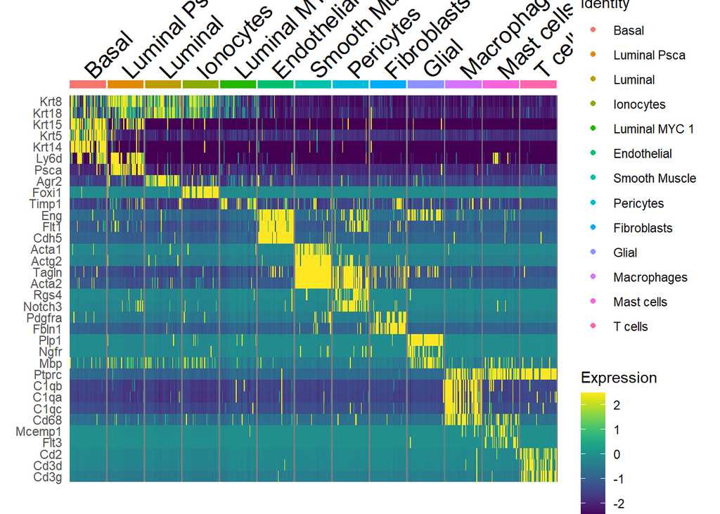

```r
Idents(seurat.int) <- "cell_type"
levels(seurat.int) <- c("Basal", "Luminal Psca", "Luminal", "Ionocytes", "Luminal MYC 1",
                        "Endothelial", "Smooth Muscle", "Pericytes", "Fibroblasts", "Glial",
                        "Macrophages",  "Mast cells", "T cells")


DoHeatmap(subset(seurat.int, downsample = 50), assay = "SCT", features = c(cell_markers)) +
  scale_fill_viridis()
```

UMAP plots

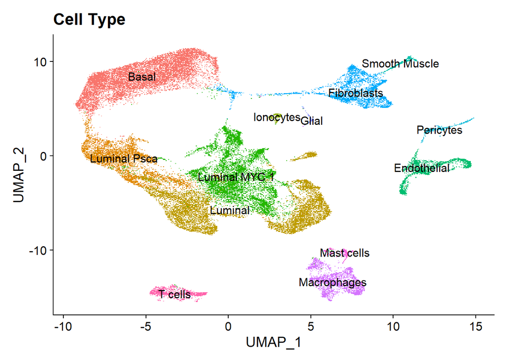

```r
DimPlot(seurat.int, reduction = "umap", label = TRUE, pt.size = 1, shuffle = TRUE, raster = TRUE) + NoLegend() + ggtitle("Cell Type")
```

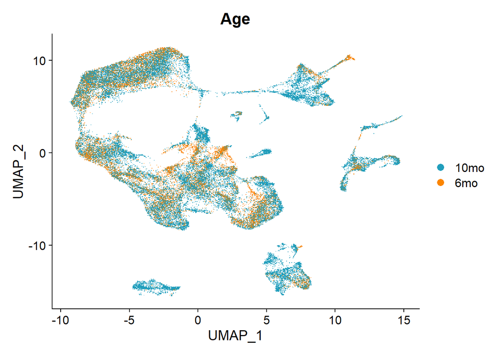

```r
# age and genotype
seurat.int$genotype <- factor(seurat.int$genotype, levels = c('WT', 'MYC'))

pal1 <- c("#219ebc", "#fb8500")
pal2 <- c("#a8dadc", "#e63946")

DimPlot(seurat.int, reduction = "umap", label = FALSE, pt.size = 1, group.by = "age", shuffle = TRUE, cols = pal1, raster = TRUE) +  ggtitle("Age")
```

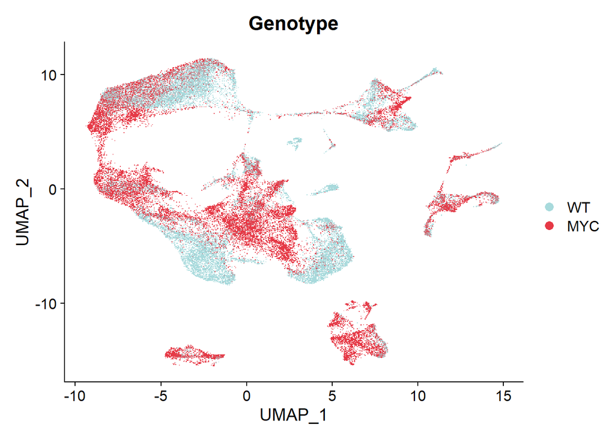

```r
DimPlot(seurat.int, reduction = "umap", label = FALSE, pt.size = 1, group.by = "genotype", shuffle = TRUE, cols = pal2, raster = TRUE) +  ggtitle("Genotype")
```

```r
# saveRDS(seurat.int, file = "FVB_DLP_int.rds")
```

# GSEA luminal HiMYC 6 months Luminal vs Luminal MYC 1

```r
library(DataCombine)
library(msigdbr)
library(presto)
library(fgsea)

# select hallmark geneset
hallmark_gene_sets <- msigdbr(species = "mouse", category = "H")
fgsea_sets<- hallmark_gene_sets %>% split(x = .$gene_symbol, f = .$gs_name)
```

6 month WT and HiMYC Luminal MYC 1 vs WT: Differential expression analysis for ranked list and GSEA for Hallmark Presto performs a fast Wilcoxon rank sum test and auROC analysis.

```r
Idents(seurat.int) <- "age"
levels(seurat.int)
```

```
## [1] "6mo"  "10mo"
```

```r
Luminal6mo_genes <- subset(seurat.int, idents = c("6mo")) %>% wilcoxauc(group_by = 'cell_type', seurat_assay = 'SCT', assay = 'data', groups_use = c("Luminal", "Luminal MYC 1"))
head(Luminal6mo_genes)
```

```
##   feature   group      avgExpr         logFC statistic       auc         pval
## 1   Sox17 Luminal 0.0007121375 -8.647329e-04   4486816 0.4993762 2.366859e-01
## 2  Mrpl15 Luminal 0.0868679560 -1.382408e-01   3727035 0.4148137 1.095024e-59
## 3  Lypla1 Luminal 0.1036904356 -4.635514e-02   4200554 0.4675157 3.559739e-11
## 4   Tcea1 Luminal 0.3060049154  1.126558e-01   5088758 0.5663716 8.202331e-28
## 5   Rgs20 Luminal 0.0002373792  1.211197e-05   4492499 0.5000087 9.706416e-01
## 6 Atp6v1h Luminal 0.2506708391  6.499813e-02   4830554 0.5376338 1.244732e-10
##           padj      pct_in     pct_out
## 1 5.022096e-01  0.10273973  0.22749431
## 2 2.434324e-58 11.91780822 28.50178746
## 3 2.114817e-10 14.04109589 20.60448489
## 4 9.252343e-27 37.84246575 25.51186220
## 5 1.000000e+00  0.03424658  0.03249919
## 6 7.174570e-10 31.64383562 24.63438414
```

```r
# saveRDS(Luminal6mo_genes, file = "GSEALuminal6mo_genes.rds")

# we have all the genes for each cluster
dplyr::count(Luminal6mo_genes, group)
```

```
##           group     n
## 1       Luminal 22831
## 2 Luminal MYC 1 22831
```

```r
# check of the gene-level statistic following wilcox rank sum test and auROC analysis
Luminal6mo_genes %>%
  dplyr::filter(group == "Luminal MYC 1") %>%
  arrange(desc(logFC), desc(statistic)) %>%
  head(n = 10)
```

```
##    feature         group  avgExpr     logFC statistic       auc          pval
## 1   Wfdc12 Luminal MYC 1 3.761086 3.2857234   8007695 0.8912451  0.000000e+00
## 2     Bex1 Luminal MYC 1 1.620568 1.2621304   7351386 0.8181988  0.000000e+00
## 3   S100a6 Luminal MYC 1 2.238883 1.1886738   6995237 0.7785600  0.000000e+00
## 4    Eef1g Luminal MYC 1 2.719923 1.1407878   7953297 0.8851907  0.000000e+00
## 5   Ifitm3 Luminal MYC 1 1.684015 1.1244820   7620709 0.8481741  0.000000e+00
## 6     Rpsa Luminal MYC 1 3.662441 1.0117588   8132087 0.9050897  0.000000e+00
## 7    H2afz Luminal MYC 1 2.297117 1.0041478   7243542 0.8061959  0.000000e+00
## 8  Wfdc15b Luminal MYC 1 1.109167 1.0023893   7352694 0.8183444  0.000000e+00
## 9    Timp1 Luminal MYC 1 1.239841 0.9953660   7189396 0.8001696  0.000000e+00
## 10 Gm26917 Luminal MYC 1 1.885612 0.9813127   6845297 0.7618719 1.151727e-274
##             padj    pct_in    pct_out
## 1   0.000000e+00  88.88528  14.246575
## 2   0.000000e+00  79.13552  33.938356
## 3   0.000000e+00  93.37017  64.863014
## 4   0.000000e+00  99.51251  97.089041
## 5   0.000000e+00  91.74521  51.095890
## 6   0.000000e+00 100.00000 100.000000
## 7   0.000000e+00  98.37504  92.191781
## 8   0.000000e+00  70.39324   7.842466
## 9   0.000000e+00  74.19565  19.246575
## 10 1.696457e-272  92.88268  73.732877
```

```r
Luminal6mo_genes %>%
  dplyr::filter(group == "Luminal MYC 1") %>%
  arrange(desc(logFC), desc(statistic)) %>%
  tail(n = 10)
```

```
##             feature         group   avgExpr     logFC statistic        auc
## 22822         Man1a Luminal MYC 1 0.2947469 -1.309482 1429560.0 0.15910801
## 22823         Ifrd1 Luminal MYC 1 1.1708479 -1.392255 1054845.0 0.11740276
## 22824         Cldn4 Luminal MYC 1 2.3779979 -1.440480  880112.0 0.09795522
## 22825          Msmb Luminal MYC 1 0.6804979 -1.641741 2184412.0 0.24312197
## 22826           B2m Luminal MYC 1 1.8893363 -1.666838  752863.5 0.08379264
## 22827 9530002B09Rik Luminal MYC 1 0.5414676 -1.907170 1207083.5 0.13434669
## 22828         Prdx6 Luminal MYC 1 1.1461220 -2.110554  911954.5 0.10149925
## 22829          Tgm4 Luminal MYC 1 0.4241007 -2.632999 1893286.0 0.21072006
## 22830 9530053A07Rik Luminal MYC 1 0.7638294 -2.706244 2040267.0 0.22707884
## 22831          Pbsn Luminal MYC 1 0.6702021 -3.620307  841068.0 0.09360968
##                pval          padj   pct_in   pct_out
## 22822  0.000000e+00  0.000000e+00 22.55444  82.53425
## 22823  0.000000e+00  0.000000e+00 82.51544  98.97260
## 22824  0.000000e+00  0.000000e+00 98.99253 100.00000
## 22825 5.529486e-277 8.251222e-275 43.02892  80.47945
## 22826  0.000000e+00  0.000000e+00 96.78258  99.93151
## 22827  0.000000e+00  0.000000e+00 27.72181  89.96575
## 22828  0.000000e+00  0.000000e+00 80.01300  97.50000
## 22829  0.000000e+00  0.000000e+00 10.26974  66.78082
## 22830  0.000000e+00  0.000000e+00 24.17940  70.20548
## 22831  0.000000e+00  0.000000e+00 23.95190  93.18493
```

```r
# select only the feature and statistic columns for fgsea
Luminal6mo_genes_group<- Luminal6mo_genes %>%
  dplyr::filter(group == "Luminal MYC 1") %>%
  arrange(desc(statistic)) %>%
  dplyr::select(feature, statistic)

ranks_Luminal6mo<- deframe(Luminal6mo_genes_group)
head(ranks_Luminal6mo)
```

```
##   Rps16  Rpl18a   Rps19    Rpsa    Rps8  Rpl13a
## 8199343 8174198 8138273 8132087 8122253 8110115
```

```r
tail(ranks_Luminal6mo)
```

```
##     Azin1     Ifrd1     Prdx6     Cldn4      Pbsn       B2m
## 1163289.5 1054845.0  911954.5  880112.0  841068.0  752863.5
```

```r
# perform analysis
fgseaRes_Luminal6mo <- fgsea(fgsea_sets, stats = ranks_Luminal6mo)
# save results
# saveRDS(fgseaRes_Luminal6mo, file = "fgseaRes_Luminal6mo.rds")

# tidy the data
fgseaResTidy_Luminal6mo <- fgseaRes_Luminal6mo %>%
  as_tibble() %>%
  arrange(padj)

# add statistic
fgseaResTidy_Luminal6mo$statistic <- -log10(fgseaResTidy_Luminal6mo$padj)

# add comparison
fgseaResTidy_Luminal6mo$comparison <- "Luminal MYC 1 vs Luminal in 6 month Mice"
```

# GSEA luminal HiMYC 6 months vs 10 months

Luminal Hi-Myc 6 months vs 10 months: Differential expression analysis for ranked list and GSEA for Hallmark Presto performs a fast Wilcoxon rank sum test and auROC analysis.

```r
seurat.int$age_genotype_celltype <- paste(seurat.int$age, seurat.int$genotype, seurat.int$cell_type, sep = " ")
Idents(seurat.int) <- "age_genotype_celltype"
levels(seurat.int)
```

```
##  [1] "6mo WT Basal"           "6mo WT Luminal"         "6mo WT Smooth Muscle"
##  [4] "6mo WT Luminal MYC 1"   "6mo WT Ionocytes"       "6mo WT Luminal Psca"
##  [7] "6mo WT Mast cells"      "6mo WT Macrophages"     "6mo WT Endothelial"
## [10] "6mo WT Fibroblasts"     "6mo WT Pericytes"       "6mo WT T cells"
## [13] "6mo WT Glial"           "6mo MYC Basal"          "6mo MYC Fibroblasts"
## [16] "6mo MYC Luminal MYC 1"  "6mo MYC Luminal Psca"   "6mo MYC Endothelial"
## [19] "6mo MYC Macrophages"    "6mo MYC Luminal"        "6mo MYC Mast cells"
## [22] "6mo MYC Pericytes"      "6mo MYC T cells"        "6mo MYC Smooth Muscle"
## [25] "6mo MYC Glial"          "6mo MYC Ionocytes"      "10mo WT Endothelial"
## [28] "10mo WT Basal"          "10mo WT Pericytes"      "10mo WT Fibroblasts"
## [31] "10mo WT Luminal"        "10mo WT Luminal MYC 1"  "10mo WT Luminal Psca"
## [34] "10mo WT Smooth Muscle"  "10mo WT Ionocytes"      "10mo WT Macrophages"
## [37] "10mo WT T cells"        "10mo WT Glial"          "10mo WT Mast cells"
## [40] "10mo MYC Fibroblasts"   "10mo MYC Luminal Psca"  "10mo MYC Luminal MYC 1"
## [43] "10mo MYC Basal"         "10mo MYC T cells"       "10mo MYC Endothelial"
## [46] "10mo MYC Mast cells"    "10mo MYC Pericytes"     "10mo MYC Macrophages"
## [49] "10mo MYC Luminal"       "10mo MYC Smooth Muscle" "10mo MYC Glial"
```

```r
Luminal_genes <- wilcoxauc(X = seurat.int, group_by = 'age_genotype_celltype', seurat_assay = 'SCT', assay = 'data', groups_use = c("6mo MYC Luminal MYC 1", "10mo MYC Luminal MYC 1"))
head(Luminal_genes)
```

```
##   feature                  group      avgExpr         logFC statistic       auc
## 1   Sox17 10mo MYC Luminal MYC 1 0.0008974715 -0.0006377382   6270978 0.4995400
## 2  Mrpl15 10mo MYC Luminal MYC 1 0.3120615963  0.0648603837   6696923 0.5334703
## 3  Lypla1 10mo MYC Luminal MYC 1 0.2438780064  0.0875032380   6907203 0.5502210
## 4   Tcea1 10mo MYC Luminal MYC 1 0.3695641348  0.1887021305   7647230 0.6091708
## 5   Rgs20 10mo MYC Luminal MYC 1 0.0017328623  0.0014769941   6289336 0.5010023
## 6 Atp6v1h 10mo MYC Luminal MYC 1 0.1539408071 -0.0265587175   5991535 0.4772798
##           pval         padj     pct_in     pct_out
## 1 3.463640e-01 5.840351e-01  0.1294778  0.22148394
## 2 1.134675e-08 4.030770e-08 36.5990505 31.19232189
## 3 2.102216e-20 1.164944e-19 30.6430729 21.48394241
## 4 3.102236e-75 4.575398e-74 44.8208891 24.06792174
## 5 4.018253e-02 8.453508e-02  0.2373759  0.03691399
## 6 4.463684e-06 1.357357e-05 19.2274493 24.21557770
```

```r
# saveRDS(Luminal_genes, file = "GSEALuminal_genes.rds")

# we have all the genes for each cluster
dplyr::count(Luminal_genes, group)
```

```
##                    group     n
## 1 10mo MYC Luminal MYC 1 22831
## 2  6mo MYC Luminal MYC 1 22831
```

```r
# check of the gene-level statistic following wilcox rank sum test and auROC analysis
Luminal_genes %>%
  dplyr::filter(group == "10mo MYC Luminal MYC 1") %>%
  arrange(desc(logFC), desc(statistic)) %>%
  head(n = 10)
```

```
##          feature                  group  avgExpr    logFC statistic       auc
## 1          Rack1 10mo MYC Luminal MYC 1 2.964243 2.920745  12543504 0.9992032
## 2           Gas5 10mo MYC Luminal MYC 1 2.065463 2.048831  12483845 0.9944508
## 3           Nme2 10mo MYC Luminal MYC 1 2.373828 1.933551  12314095 0.9809287
## 4          Hspa5 10mo MYC Luminal MYC 1 2.901932 1.824785  11759959 0.9367868
## 5         mt-Co2 10mo MYC Luminal MYC 1 3.927993 1.801023  11738711 0.9350942
## 6        Gm42418 10mo MYC Luminal MYC 1 3.337256 1.787125  11116920 0.8855630
## 7  5430419D17Rik 10mo MYC Luminal MYC 1 2.212730 1.675073  11308842 0.9008512
## 8         Tceal9 10mo MYC Luminal MYC 1 1.613090 1.612322  12329745 0.9821754
## 9          Defb1 10mo MYC Luminal MYC 1 3.159710 1.498470  10420867 0.8301160
## 10       mt-Nd4l 10mo MYC Luminal MYC 1 1.645482 1.488391  11895058 0.9475487
##    pval padj   pct_in   pct_out
## 1     0    0 99.89210  6.275378
## 2     0    0 99.09366  2.399409
## 3     0    0 99.76262 51.753415
## 4     0    0 99.61157 78.331488
## 5     0    0 99.78420 99.446290
## 6     0    0 99.97842 93.060170
## 7     0    0 95.66249 51.199705
## 8     0    0 96.46094  0.110742
## 9     0    0 95.85671 84.274640
## 10    0    0 94.64825 19.896641
```

```r
Luminal_genes %>%
  dplyr::filter(group == "10mo MYC Luminal MYC 1") %>%
  arrange(desc(logFC), desc(statistic)) %>%
  tail(n = 10)
```

```
##          feature                  group   avgExpr     logFC statistic
## 22822      Tceb2 10mo MYC Luminal MYC 1 0.0000000 -1.531657  210847.0
## 22823       Wbp5 10mo MYC Luminal MYC 1 0.0000000 -1.533840  472668.0
## 22824       Selk 10mo MYC Luminal MYC 1 0.0000000 -1.534748  266455.0
## 22825 Rpl23a-ps3 10mo MYC Luminal MYC 1 0.0000000 -1.570051  254870.0
## 22826  Rpl10-ps3 10mo MYC Luminal MYC 1 0.2709752 -1.675239  259080.5
## 22827      Zfos1 10mo MYC Luminal MYC 1 0.0000000 -1.686618  356818.0
## 22828      Wdr89 10mo MYC Luminal MYC 1 0.2895306 -2.088260   59226.0
## 22829    Gm10709 10mo MYC Luminal MYC 1 0.1240007 -2.527353   11755.0
## 22830     Gnb2l1 10mo MYC Luminal MYC 1 0.1534676 -3.136669    9003.0
## 22831     Gm8730 10mo MYC Luminal MYC 1 0.2037260 -3.790870    3679.0
##                auc pval padj   pct_in  pct_out
## 22822 0.0167958656    0    0  0.00000 96.64083
## 22823 0.0376522702    0    0  0.00000 92.46955
## 22824 0.0212255445    0    0  0.00000 95.75489
## 22825 0.0203026947    0    0  0.00000 95.93946
## 22826 0.0206380990    0    0 36.08114 97.93282
## 22827 0.0284237726    0    0  0.00000 94.31525
## 22828 0.0047178852    0    0 38.23910 99.63086
## 22829 0.0009363918    0    0 17.88951 99.85234
## 22830 0.0007171702    0    0 22.14070 99.88926
## 22831 0.0002930655    0    0 29.39145 99.96309
```

```r
# select only the feature and statistic columns for fgsea
Luminal_genes_group<- Luminal_genes %>%
  dplyr::filter(group == "10mo MYC Luminal MYC 1") %>%
  arrange(desc(statistic)) %>%
  dplyr::select(feature, statistic)

ranks_Luminal<- deframe(Luminal_genes_group)
head(ranks_Luminal)
```

```
##    Rack1     Gas5     Elob   Tceal9     Nme2  Selenok
## 12543504 12483845 12391101 12329745 12314095 12239082
```

```r
tail(ranks_Luminal)
```

```
##    Tceb2    Rps18    Wdr89  Gm10709   Gnb2l1   Gm8730
## 210847.0 199588.5  59226.0  11755.0   9003.0   3679.0
```

```r
# perform analysis
fgseaRes_Luminal <- fgsea(fgsea_sets, stats = ranks_Luminal)
# save results
# saveRDS(fgseaRes_Luminal, file = "fgseaRes_Luminal.rds")

# tidy the data
fgseaResTidy_Luminal <- fgseaRes_Luminal %>%
  as_tibble() %>%
  arrange(padj)

# add statistic
fgseaResTidy_Luminal$statistic <- -log10(fgseaResTidy_Luminal$padj)

# add comparison
fgseaResTidy_Luminal$comparison <- "Luminal MYC 1 10 months vs 6 months"
```

Plot fgsea results from two different comparison

```r
library(forcats)

fgseaResTidy_Luminal6mo$sort <- fgseaResTidy_Luminal6mo$NES
fgseaResTidy_Luminal$sort <- NA

# combine fgsea dataframes
fgsea_combineDF <- rbind(fgseaResTidy_Luminal6mo, fgseaResTidy_Luminal)
fgsea_combineDF <- fgsea_combineDF %>% group_by(pathway) %>%
  mutate(NES_diff=NES-lag(NES))

# sort
fgsea_combineDF <- fgsea_combineDF %>% arrange(sort)

# top changes
fgsea_diff_top <- fgsea_combineDF %>% arrange(desc(abs(NES_diff))) %>% head(13) %>% arrange(sort)
fgsea_diff_top
```

```
## # A tibble: 13 x 12
## # Groups:   pathway [13]
##    pathway        pval     padj log2err     ES   NES  size leadingEdge statistic
##    <chr>         <dbl>    <dbl>   <dbl>  <dbl> <dbl> <int> <list>          <dbl>
##  1 HALLMARK_~ 1.77e-28 2.22e-27   1.39   0.419  5.87   197 <chr [103]>     26.7
##  2 HALLMARK_~ 1.96e-13 8.92e-13   0.944  0.404  4.19    96 <chr [49]>      12.0
##  3 HALLMARK_~ 6.17e-15 3.09e-14   0.997  0.402  4.42   111 <chr [52]>      13.5
##  4 HALLMARK_~ 4.95e-24 4.95e-23   1.27   0.384  5.38   198 <chr [100]>     22.3
##  5 HALLMARK_~ 2.00e-15 1.43e-14   1.01  -0.281 -4.78   194 <chr [131]>     13.8
##  6 HALLMARK_~ 3.65e-10 1.22e- 9   0.814 -0.260 -3.84   149 <chr [79]>       8.92
##  7 HALLMARK_~ 1.09e- 6 2.28e- 6   0.644 -0.171 -2.92   198 <chr [110]>      5.64
##  8 HALLMARK_~ 1.25e-10 4.47e-10   0.827  0.349  3.75   105 <chr [49]>       9.35
##  9 HALLMARK_~ 9.80e-11 3.77e-10   0.839 -0.233 -4.02   197 <chr [122]>      9.42
## 10 HALLMARK_~ 6.09e- 9 1.71e- 8   0.761 -0.322 -3.71    85 <chr [59]>       7.77
## 11 HALLMARK_~ 8.43e- 6 1.50e- 5   0.593 -0.157 -2.67   198 <chr [108]>      4.82
## 12 HALLMARK_~ 6.16e- 9 1.71e- 8   0.761  0.270  3.44   157 <chr [52]>       7.77
## 13 HALLMARK_~ 1.05e- 6 2.28e- 6   0.644 -0.177 -3.01   194 <chr [108]>      5.64
## # i 3 more variables: comparison <chr>, sort <dbl>, NES_diff <dbl>
```

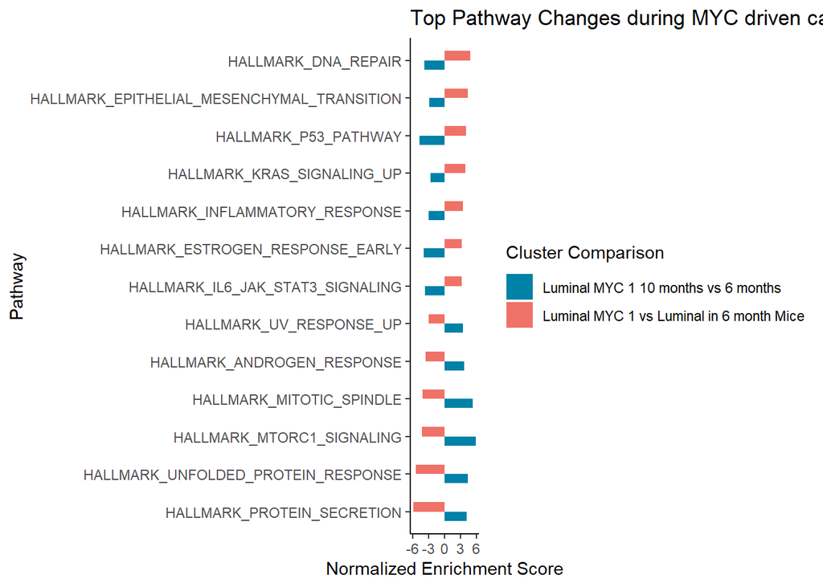

```r
## only plot the top pathway differences
pal3 <- c("#0081a7", "#f07167")

ggplot(fgsea_combineDF %>% filter(pathway %in% fgsea_diff_top$pathway),
       aes(x = fct_inorder(pathway), NES)) +
  geom_col(aes(fill= comparison),width=.5, position = "dodge") +
  coord_flip() +
  labs(x="Pathway", y="Normalized Enrichment Score",
       title="Top Pathway Changes during MYC driven cancer progression") +
  theme_classic() + labs(fill =  expression("Cluster Comparison")) +
  scale_fill_manual(values=pal3)
```

Top 20 leading edge genes

```r
# P53 leading edge
leadingEdge_P53_late <- fgseaRes_Luminal %>% filter(pathway == "HALLMARK_P53_PATHWAY") %>% select(leadingEdge) %>% unlist() %>% as.data.frame() %>% head(20)

# DNA repair leading edge
leadingEdge_DNA_late <- fgseaRes_Luminal %>% filter(pathway == "HALLMARK_DNA_REPAIR") %>% select(leadingEdge) %>% unlist() %>% as.data.frame() %>% head(20)

# Inflammatory leading edge
leadingEdge_inflame_late <- fgseaRes_Luminal %>% filter(pathway == "HALLMARK_INFLAMMATORY_RESPONSE") %>% select(leadingEdge) %>% unlist() %>% as.data.frame() %>% head(20)

# IL6 leading edge
leadingEdge_IL6_late <- fgseaRes_Luminal %>% filter(pathway == "HALLMARK_IL6_JAK_STAT3_SIGNALING") %>% select(leadingEdge) %>% unlist() %>% as.data.frame() %>% head(20)
```

heatmap of key pathways

```r
# complex heatmap
library(tidyverse)
library(RColorBrewer)
library(ComplexHeatmap)
library(wesanderson)

# expression matrix
Idents(seurat.int) <- "cell_type"
levels(seurat.int)
```

```
##  [1] "Basal"         "Luminal"       "Smooth Muscle" "Luminal MYC 1"
##  [5] "Ionocytes"     "Luminal Psca"  "Mast cells"    "Macrophages"
##  [9] "Endothelial"   "Fibroblasts"   "Pericytes"     "T cells"
## [13] "Glial"
```

```r
luminalMYC1_seurat <- subset(seurat.int, idents = c("Luminal MYC 1", "Luminal"))

luminalMYC1_seurat$age_celltype <- paste(luminalMYC1_seurat$age, luminalMYC1_seurat$cell_type, sep = " ")

Idents(luminalMYC1_seurat) <- "age_celltype"
levels(luminalMYC1_seurat)
```

```
## [1] "6mo Luminal"        "6mo Luminal MYC 1"  "10mo Luminal"
## [4] "10mo Luminal MYC 1"
```

```r
AvgExp <- AverageExpression(luminalMYC1_seurat)
```

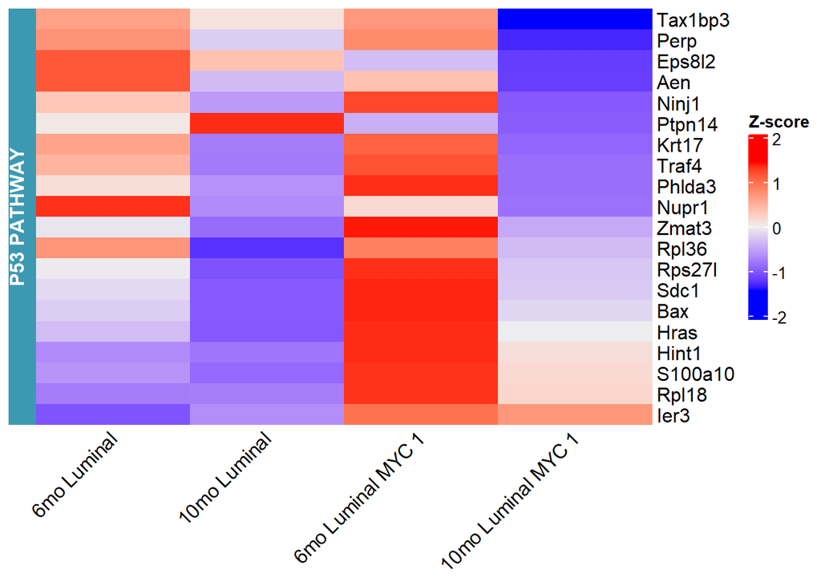

```r
AvgExp_SCT <- AvgExp$SCT

# row standardization
AvgExp_scale <- t(apply(AvgExp_SCT, 1, scale))
colnames(AvgExp_scale) <- colnames(AvgExp_SCT)
AvgExp_scale <- AvgExp_scale %>% na.omit() %>% as.data.frame()

# filter expression heatmap to leading edge genes
AvgExp_p53 <- filter(AvgExp_scale, rownames(AvgExp_scale) %in% c(leadingEdge_P53_late$.)) %>% arrange(`10mo Luminal MYC 1`) %>% as.matrix()
p53_gene_order <- rownames(AvgExp_p53)

AvgExp_DNA <- filter(AvgExp_scale, rownames(AvgExp_scale) %in% c(leadingEdge_DNA_late$.)) %>% arrange(`10mo Luminal MYC 1`) %>% as.matrix()
DNA_gene_order <- rownames(AvgExp_DNA)

AvgExp_inflame <- filter(AvgExp_scale, rownames(AvgExp_scale) %in% c(leadingEdge_inflame_late$.)) %>% arrange(`10mo Luminal MYC 1`) %>% as.matrix()
inflame_gene_order <- rownames(AvgExp_inflame)

AvgExp_IL6 <- filter(AvgExp_scale, rownames(AvgExp_scale) %in% c(leadingEdge_IL6_late$.)) %>% arrange(`10mo Luminal MYC 1`) %>% as.matrix()
IL6_gene_order <- rownames(AvgExp_IL6)

# sample order
sample_order <- c("6mo Luminal","10mo Luminal", "6mo Luminal MYC 1", "10mo Luminal MYC 1")

# sort by z score of Luminal MYC 1 9 month for column order, concatenate for top 20 of each leading edge pathway
pal <- wes_palette("Zissou1", 5, type = "discrete")

# complex heatmap
P53 <- Heatmap(AvgExp_p53,
               name = "P53",
        column_order = sample_order,
        row_order = p53_gene_order,
        row_dend_reorder = FALSE,
        show_row_dend = FALSE,
        show_column_dend = FALSE,
        row_names_side = "right",
        row_title = "P53 PATHWAY",
        row_title_gp = gpar(fill = pal[1], col = "white", border = NA, fontface = "bold"),
        row_names_gp = gpar(fontsize = 12),
        column_names_rot = 45,
        heatmap_legend_param = list(
          title = "Z-score",
          legend_height = unit(4, "cm")
        ))

P53
```

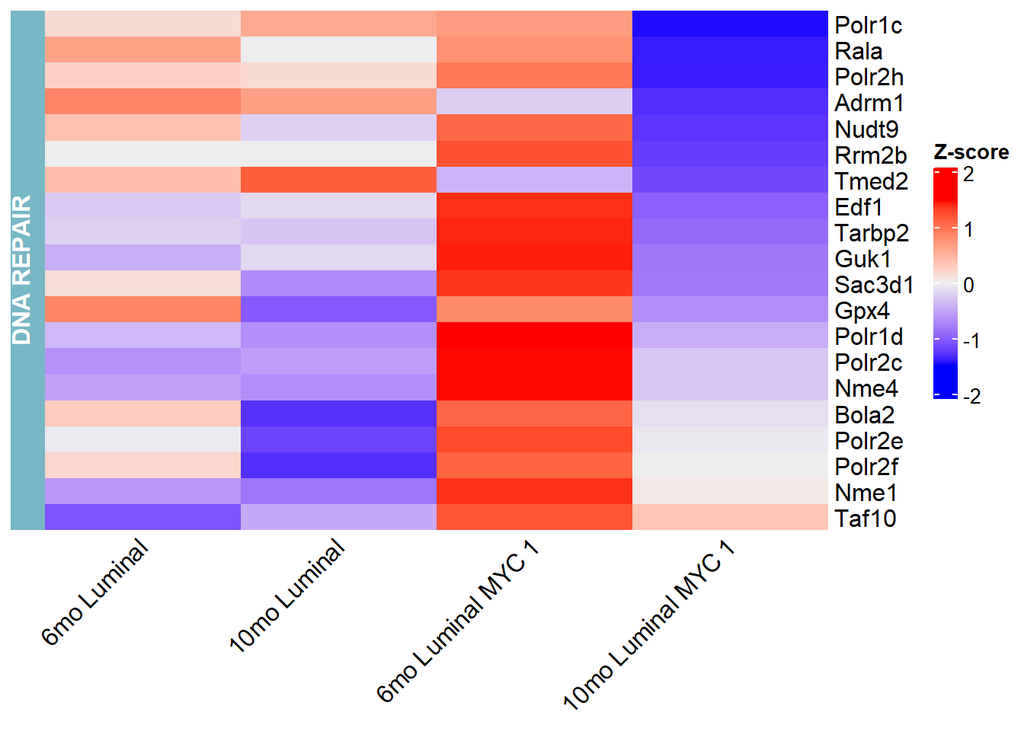

```r
DNA <- Heatmap(AvgExp_DNA,
               column_order = sample_order,
               row_order = DNA_gene_order,
               name = "DNA",
               column_dend_reorder = FALSE,
               show_row_dend = FALSE,
               show_column_dend = FALSE,
               row_names_side = "right",
               row_title = "DNA REPAIR",
               row_title_gp = gpar(fill = pal[2], col = "white", border = NA, fontface = "bold"),
               row_names_gp = gpar(fontsize = 12),
               column_names_rot = 45,
               heatmap_legend_param = list(
                 title = "Z-score",
                 legend_height = unit(4, "cm")
               ))

DNA
```

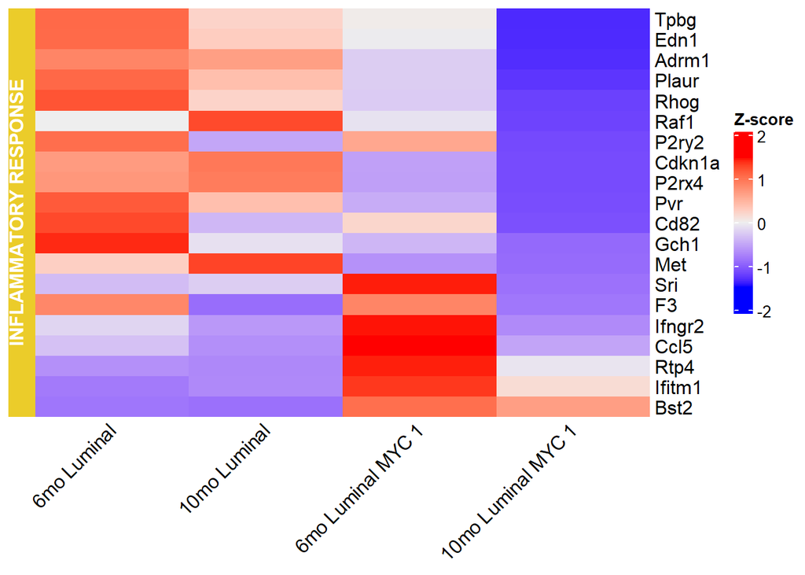

```r
Inflame <- Heatmap(AvgExp_inflame,
               name = "Inflame",
               column_order = sample_order,
               row_order = inflame_gene_order,
               row_dend_reorder = FALSE,
               show_row_dend = FALSE,
               show_column_dend = FALSE,
               row_names_side = "right",
               row_title = "INFLAMMATORY RESPONSE",
               row_title_gp = gpar(fill = pal[3], col = "white", border = NA, fontface = "bold"),
               row_names_gp = gpar(fontsize = 12),
               column_names_rot = 45,
               heatmap_legend_param = list(
                 title = "Z-score",
                 legend_height = unit(4, "cm")
               ))

Inflame
```

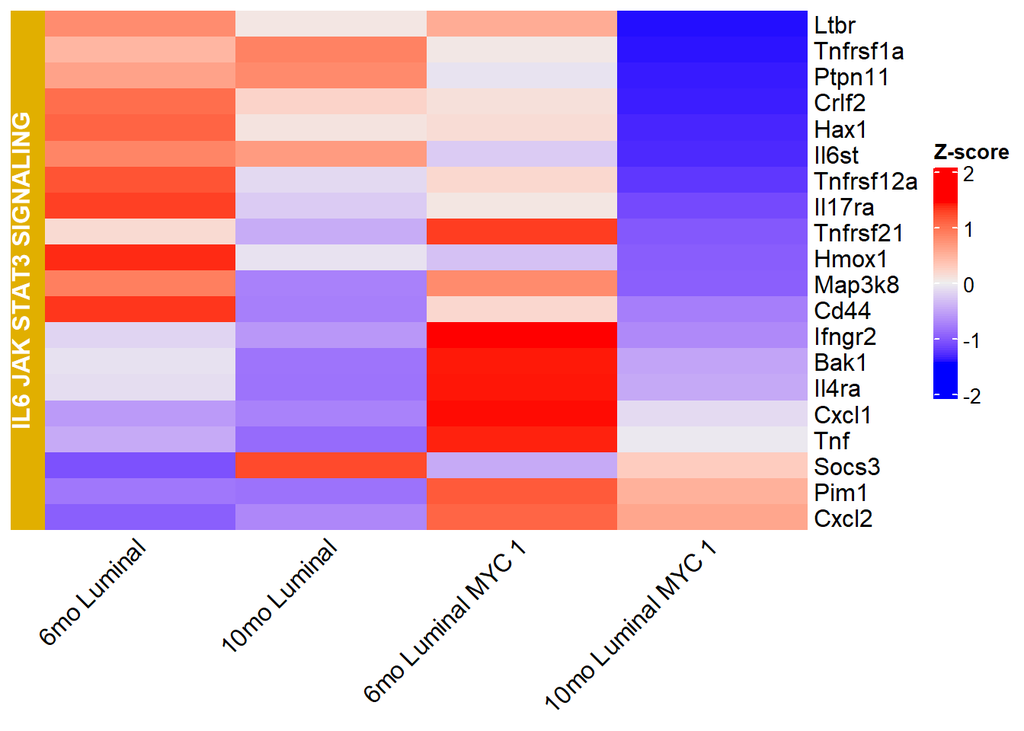

```r
IL6 <- Heatmap(AvgExp_IL6,
        column_order = sample_order,
        row_order = IL6_gene_order,
        name = "IL6",
        column_dend_reorder = FALSE,
        show_row_dend = FALSE,
        show_column_dend = FALSE,
        row_names_side = "right",
        row_title = "IL6 JAK STAT3 SIGNALING",
        row_title_gp = gpar(fill = pal[4], col = "white", border = NA, fontface = "bold"),
        row_names_gp = gpar(fontsize = 12),
        column_names_rot = 45,
        heatmap_legend_param = list(
          title = "Z-score",
          legend_height = unit(4, "cm")
        ))

IL6
```

# save seurat object

```
saveRDS(seurat.int, file = "FVB_DLP_int.rds")
```